# Exploratory Data Analysis

Trent Meyer

2022-11-04

```r
rm(list = ls())
library(tidyverse)
library(here)
library(ggfortify)
library(lubridate)
tick_adult <- read.csv(here("Data", "Deer_Tick_Surveillance__Adults__Oct_to_Dec__excluding_Powassan_virus__Beginning_2008.csv"))
tick_nymph <- read.csv(here("Data", "Deer_Tick_Surveillance__Nymphs__May_to_Sept__excluding_Powassan_virus__Beginning_2008.csv"))
```

Let’s rename the parasite and bacteria variables:

```r
tick_adult <- tick_adult %>% rename(B.burgdorferi = "B..burgdorferi....",
                                    A.phagocytophilum = "A..phagocytophilum....",
                                    B.microti = "B..microti....",
                                    B.miyamotoi = "B..miyamotoi....")
```

County was read in as a character, instead we want it as a factor

```r
tick_adult <- tick_adult %>% mutate(County = as.factor(County),
                                    Year = paste0("01-01-", Year))

tick_adult <- tick_adult %>% mutate(Year = mdy(Year),
                                    Year = year(Year))

tick_nymph <- tick_nymph %>% mutate(County = as.factor(County),
                                    Year = as.factor(Year))
```

Let’s graph total ticks collected to see what the distribution looks like.

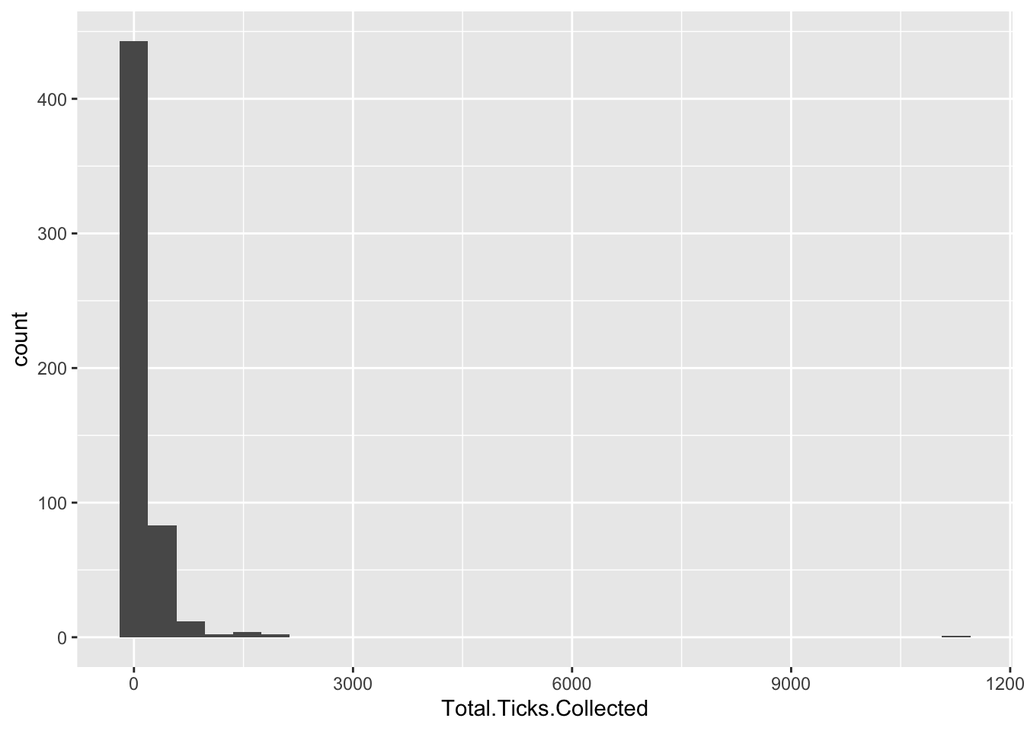

```r
ggplot(data = tick_adult, aes(x = Total.Ticks.Collected)) +
  geom_histogram()
```

We see that there is one observation with almost 12,000 ticks collected! I want to see now

```r
tick_adult$Total.Ticks.Collected
```

```
##   [1]   366   199   438    88   114   271    75   131   157    51    60    59
##  [13]   157    72   161   177     5     8    85   115   326    51   214   222
##  [25]   779   110   288   226   128   141    96   101    99    15   123   229
##  [37]   129   146    74    64   641   167  1470   515    90   122    58   212
##  [49]   111    59    89   127    25   195    51    77   173   138 11260   163
##  [61]   131    52   143   118   225    54    58    88   127   107   100    70
##  [73]   177   227    83    64   102    57    74   106    99   108     1    56
##  [85]    90   137   124  1595   154    23   610    78    74    72   178   110
##  [97]   111    85   563   118    16   295   694   200    77   365  1893   152
## [109]   199   161   103   103    12   314    76    97   136   107   169    54
## [121]   196   115   567    57    50     4   598   116   500    54   493   230
## [133]   145    30   185    81   141    19    29   309   422   577   151   458
## [145]   123    50   226   117   217   133    19   366   156    70   151   124
## [157]   129   667   158   760  1779   109     2   911   190   296    16   109
## [169]   137   126   120   232    68   348   139   477    97   101    60   120
```

[output cut: 31 more lines]

I found that there is an observation with 11,260 ticks collected! I am not sure if this is a mistake, or if they actually found this many ticks. I am leaning towards this being a true data point just because of where I got the data from.

```r
tick_adult %>% filter(Total.Ticks.Collected > 9000)
```

```
##   Year      County Total.Sites.Visited Total.Ticks.Collected
## 1 2018 Westchester                   2                 11260
##   Tick.Population.Density Total.Tested B.burgdorferi A.phagocytophilum
## 1                      11           90          44.4               8.9
##   B.microti B.miyamotoi          County.Centroid
## 1        10         5.6 (41.1527698, -73.745912)
```

```r
summary(tick_adult)
```

```
##       Year           County    Total.Sites.Visited Total.Ticks.Collected
##  Min.   :2008   Albany  : 14   Min.   : 1.000      Min.   :    0.0
##  1st Qu.:2013   Columbia: 14   1st Qu.: 1.000      1st Qu.:   54.0
##  Median :2016   Dutchess: 14   Median : 2.000      Median :  101.0
##  Mean   :2015   Monroe  : 14   Mean   : 2.486      Mean   :  169.4
##  3rd Qu.:2019   Onondaga: 14   3rd Qu.: 3.000      3rd Qu.:  158.0
##  Max.   :2021   Orange  : 14   Max.   :28.000      Max.   :11260.0
##                 (Other) :463
##  Tick.Population.Density  Total.Tested    B.burgdorferi    A.phagocytophilum
##  Min.   :   0.00         Min.   :  0.00   Min.   :  0.00   Min.   : 0.000
##  1st Qu.:  14.14         1st Qu.: 50.00   1st Qu.: 37.50   1st Qu.: 0.000
##  Median :  32.66         Median : 51.00   Median : 50.00   Median : 3.800
##  Mean   :  48.37         Mean   : 75.05   Mean   : 46.62   Mean   : 6.276
##  3rd Qu.:  60.08         3rd Qu.: 98.00   3rd Qu.: 58.83   3rd Qu.:11.225
##  Max.   :1031.00         Max.   :500.00   Max.   :100.00   Max.   :44.100
##  NA's   :1                                NA's   :27       NA's   :27
##    B.microti       B.miyamotoi     County.Centroid
##  Min.   : 0.000   Min.   : 0.000   Length:547
##  1st Qu.: 0.000   1st Qu.: 0.000   Class :character
##  Median : 0.000   Median : 0.500   Mode  :character
##  Mean   : 2.895   Mean   : 1.168
##  3rd Qu.: 4.000   3rd Qu.: 2.000
##  Max.   :32.000   Max.   :10.000
##  NA's   :27       NA's   :221
```

When I look at this, I see a lot of maximums that are much, much higher than the mean. Also, I can see that there is a mean of 2.486 total sites visited, however the maximum is 28. I also see that there are 221 NA’s for B. miyamatoi, and when I saw this there are only NA’s from 2008 to 2014, so maybe that was an issue where they were not testing for that until 2015.

# Is there an association between the number of ticks collected and year?

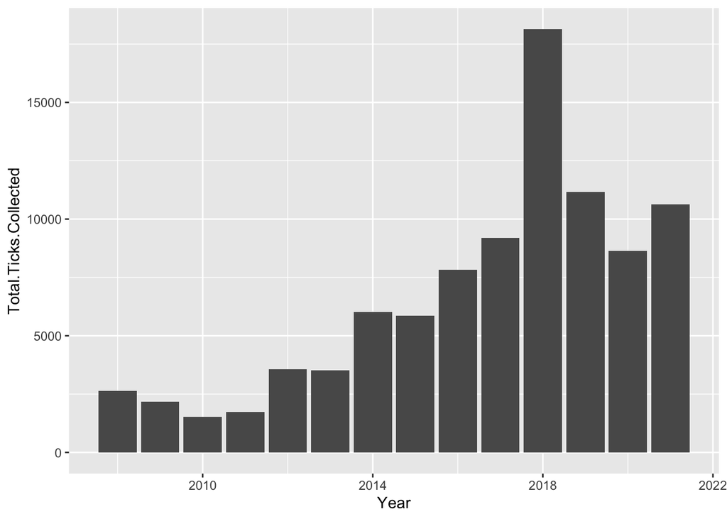

```r
ggplot(data = tick_adult, aes(x = Year, y = Total.Ticks.Collected)) +
  geom_col()
```

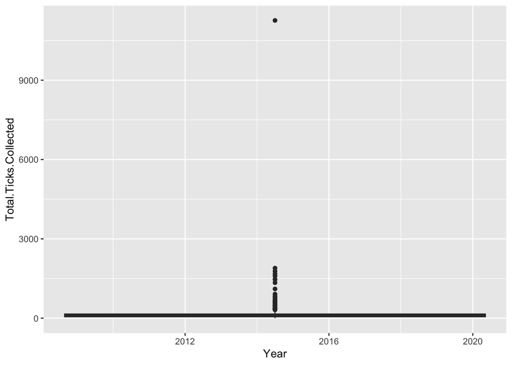

```r
ggplot(data = tick_adult, aes(x = Year, y = Total.Ticks.Collected)) +
  geom_boxplot()
```

This is a tough plot to read into just because of 2018. where there is the one point with 11,260 ticks collected. The more I think about it, I might try to get rid of this point, as I am guessing that it will have high leverage on our statistical test.

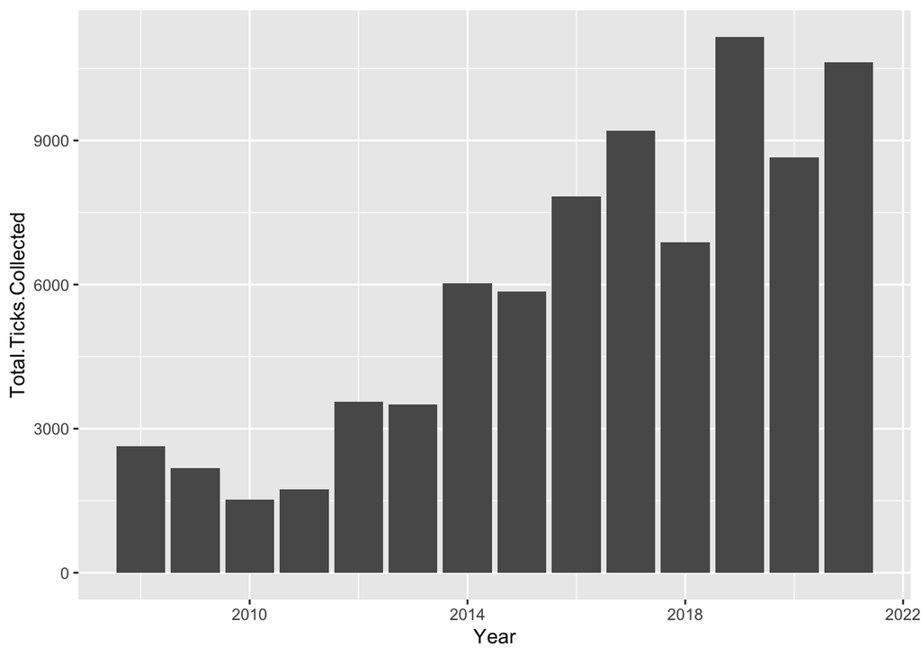

```r
tick_adult <- tick_adult %>% filter(Total.Ticks.Collected < 9000)

ggplot(data = tick_adult, aes(x = Year, y = Total.Ticks.Collected)) +
  geom_col()
```

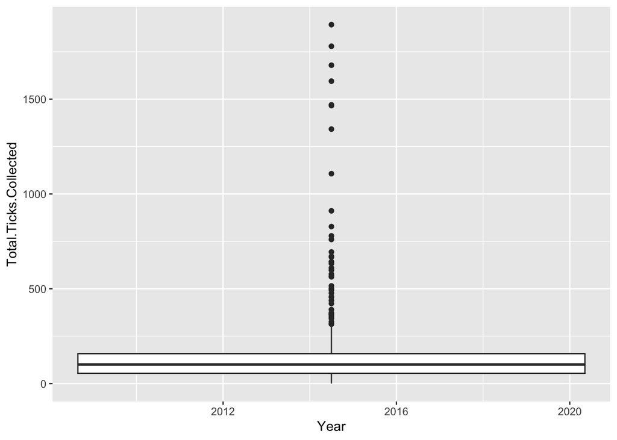

```r
ggplot(data = tick_adult, aes(x = Year, y = Total.Ticks.Collected)) +
  geom_boxplot()
```

Now these plots are much easier to read, and give me an idea of whether or not there is an association between year and total ticks collected.

# Is there an association between the number of ticks collected and Region (instead of county)?

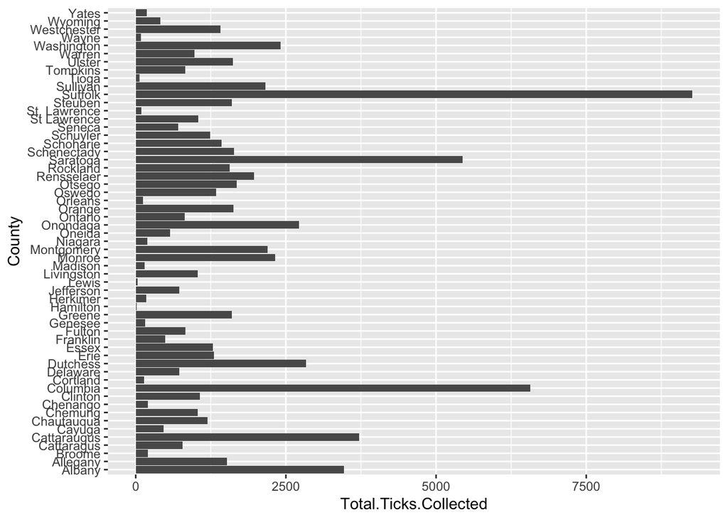

```r
ggplot(data = tick_adult, aes(x = County, y = Total.Ticks.Collected)) +
  geom_col() +
  coord_flip()
```

This plot and question are difficult to answer so I think I am going to create a variable for Region, and test if there is a difference between the 9 regions in NYS.

```r
tick_adult <- tick_adult %>% mutate(Region = case_when(
  County == "Suffolk" | County == "Nassau" ~ "Long Island",

  County == "Brooklyn" | County == "Bronx" | County == "Manhattan" |
    County == "Staten Island" | County == "Queens" ~ "New York City",

  County == "Dutchess" | County == "Orange" | County == "Putnam" |
    County == "Rockland" | County == "Sullivan" | County == "Ulster" |
    County == "Westchester" ~ "Hudson Valley",

  County == "Niagara" | County == "Erie" | County == "Chautauqua" |
    County == "Cattaragus" | County == "Cattaraugus" |
    County == "Allegany" ~ "Western New York",

  County == "Orleans" | County == "Genesee" | County == "Wyoming" |
    County == "Monroe" | County == "Livingston" | County == "Wayne" |
    County == "Ontario" | County == "Yates" | County == "Seneca" ~ "Finger Lakes",

  County == "Steuben" | County == "Schuyler" | County == "Chemung" |
    County == "Tompkins" | County == "Tioga" | County == "Chenango"
  | County == "Broome" | County == "Delaware" ~ "Southern Tier",

  County == "Cortland" | County == "Cayuga" | County == "Onondaga" |
    County == "Oswego" | County == "Madison" ~ "Central New York",

  County == "St. Lawrence" | County == "St Lawrence" | County == "Lewis" |
    County == "Jefferson" | County == "Hamilton" | County == "Essex" |
    County == "Clinton" | County == "Franklin" ~ "North Country",

  County == "Oneida" | County == "Herkimer" | County == "Fulton" |
    County == "Montgomery" | County == "Otsego" |
    County == "Schoharie" ~ "Mohawk Valley",

  County == "Albany" | County == "Columbia" | County == "Greene" |
    County == "Warren" | County == "Washington" | County == "Saratoga" |
    County == "Schenectady" | County == "Rensselaer" ~ "Capital District"
))
```

Oof, that was a lot about code, now let’s replot this by Region!

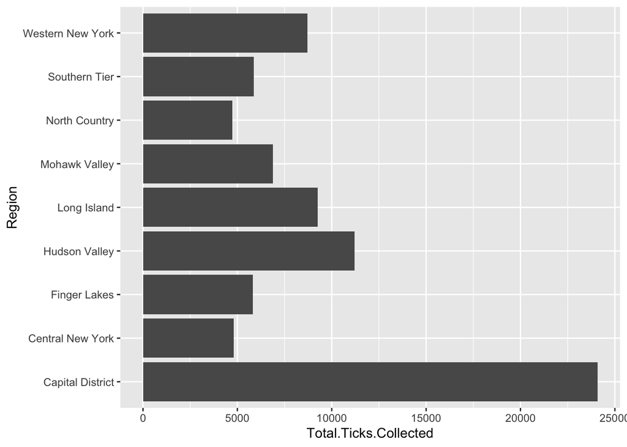

```r
ggplot(data = tick_adult, aes(x = Region, y = Total.Ticks.Collected)) +
  geom_col() +
  coord_flip()
```

It looks like there are possible differences, with Capital Region being much higher, and also possibly Hudson Valley have a higher number?

# Is there a difference in the number of total ticks collected between Year, Region, and Total Ticks Collected?

```r
tick_adult_total <- tick_adult %>% group_by(Region, Year) %>% summarise(total_ticks_collected = sum(Total.Ticks.Collected))
```

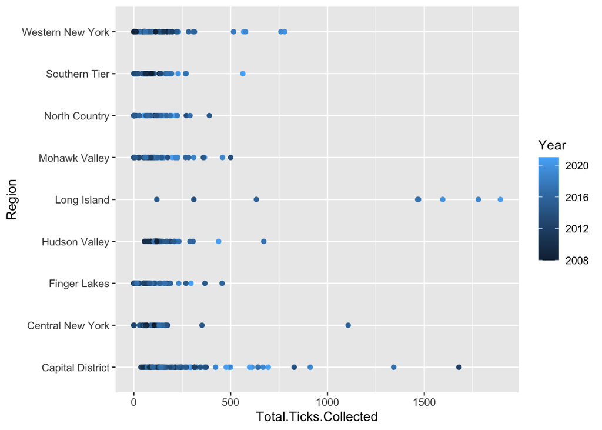

```r
ggplot(data = tick_adult, aes(x = Region, y = Total.Ticks.Collected)) +
  geom_point(aes(colour = Year)) +
  coord_flip()
```

# Is there an association between Region and B.burgdorferi?

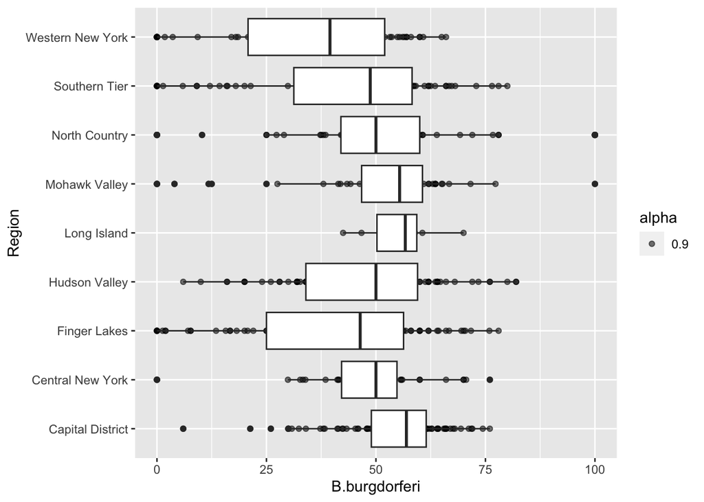

```r
ggplot(data = tick_adult, aes(x = Region, y = B.burgdorferi)) +
  geom_point(aes(alpha = 0.9)) +
  geom_boxplot() +
  coord_flip()
```

There are possibly different means, however the spread overlaps a lot.

# Is there an association between Region and A.phagocytophilum?

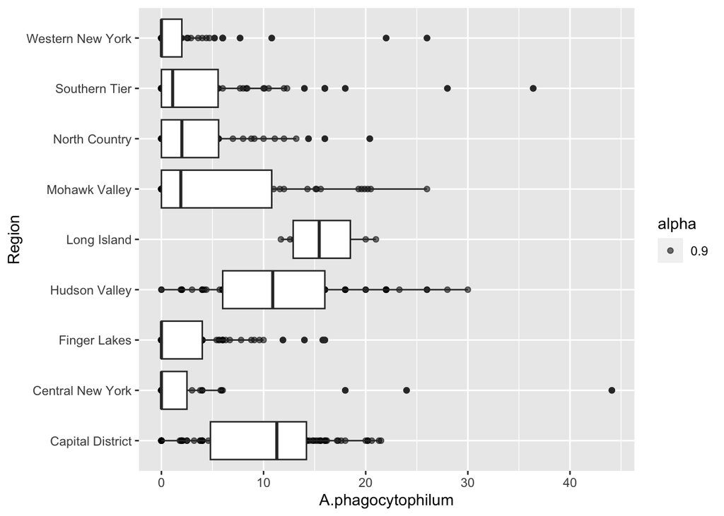

```r
ggplot(data = tick_adult, aes(x = Region, y = A.phagocytophilum)) +
  geom_point(aes(alpha = 0.9)) +
  geom_boxplot() +
  coord_flip()
```

Here it looks more likely to be a difference in mean, specifically with the Long Island, Hudson Valley, and Capital District regions looking to be higher than the rest.

# Is there an association between Region and B.microti?

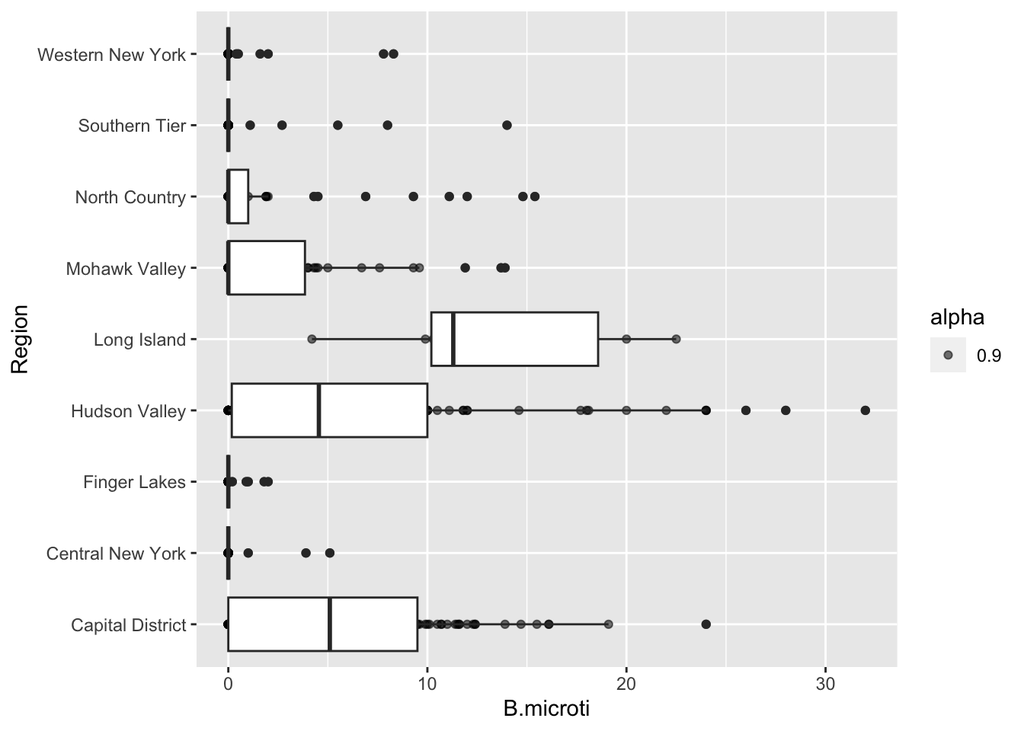

```r
ggplot(data = tick_adult, aes(x = Region, y = B.microti)) +
  geom_point(aes(alpha = 0.9)) +
  geom_boxplot() +
  coord_flip()
```

There is lots of spread for the three regions again, I think their means look higher, but I would need to test to be certain.

# Is there an association between Region and B.miyamotoi?

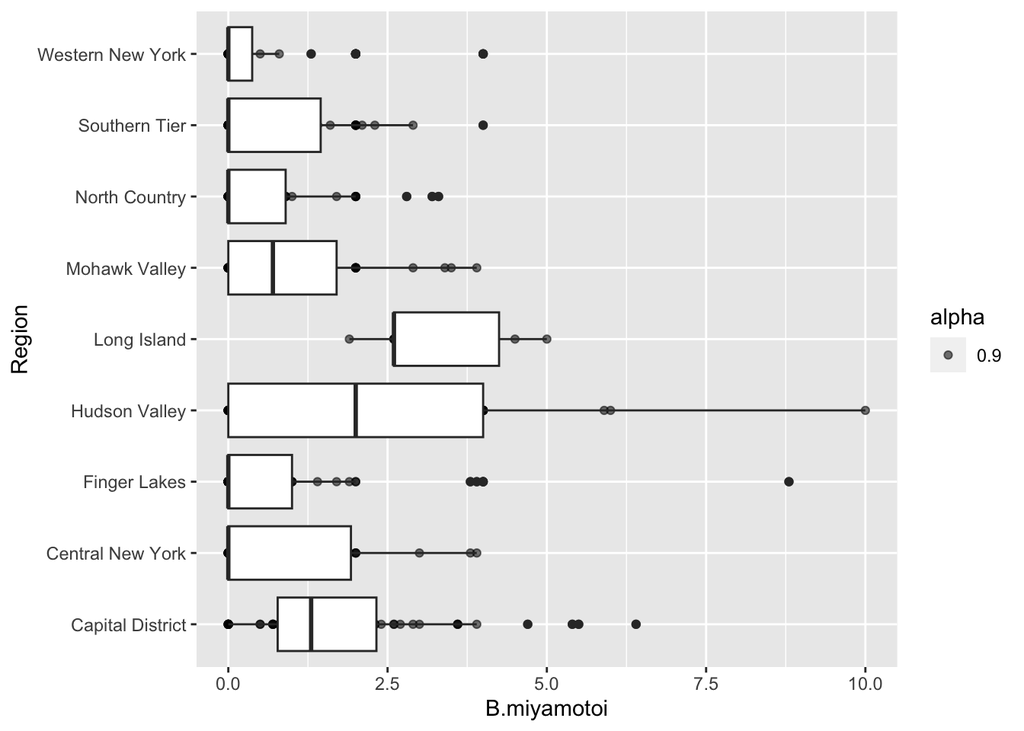

```r
ggplot(data = tick_adult, aes(x = Region, y = B.miyamotoi)) +
  geom_point(aes(alpha = 0.9)) +
  geom_boxplot() +
  coord_flip()
```

This one is not as obvious that there could be a difference in the means. I would need to see, but I think this one could have the highest p-value of the four variables.